# Projeções no Tempo e no Espaço

Fundamentos de Modelagem de Distribuição de Espécies no R - PPGBV 2021

Luíz Fernando Esser

28/06/2021

## Introdução

### Revisão da última aula

1. Montando a função de processamento;
2. Validando modelos;
3. Exercício.  
   E lembre-se: Garbage in, garbage out.  
   E mais: dados de presença/ausência refletem uma condição ambiental e não geográfica.

### Na aula de hoje

1. Exercício da aula passada;
2. Preparando os dados;
3. Montando os modelos;
4. Selecionando quais modelos projetar;
5. Projetar modelos selecionados;
6. Montando um ensemble.

## Exercício da aula passada

Enunciado: Agora é a sua vez de por a mão na massa. Alterne os parâmetros de validação (p.ex. aumentar número de rodadas ou diminuir o número de cv.folds) e compare os valores que retornaram. Tente também manter fixos os parâmetros de validação, mas alternando os critérios para binarização. Alguma dessas configurações possui maior AUC/TSS? Faz sentido seguir a abordagem unicamente pela maior métrica? Ou existe algum impeditivo biológico?  
Uma sugestão de resolução:

```r
library(sdm)
library(raster)
library(rgeos)
library(adehabitatHR)
```

Importar dados da ambientais e da espécie:

[figure not shown]

```r
df <- read.csv("spp_data/Ficus.csv")
df2 <- df[,-c(1:2)]
coordinates(df2) <- 2:3
s <- stack("current.tif")
names(s) <- c("temp", "prec")
plot(s)
```

Criar função de pré-processamento usando a função de pseudoausências da última aula:

```r
pseudoabsences <- function(sp, env){
  require(sdm)
  require(raster)
  print(paste0("Building SRE..."))
  d <- sdmData(reformulate(termlabels = names(env), response = names(sp)),
               train = sp,
               predictors = env)
  m <- sdm(~.,
           data = d,
           method='bioclim')
  p <- predict(m, env)
  p[p[]>0] <- NA
  print(paste0("Masking environment..."))
  env2 <- mask(env, p)
  print(paste0("Obtaining pseudoabsences..."))
  pa <- sampleRandom(env2, nrow(sp), sp = TRUE, na.rm=T)
  pa2 <- as.data.frame(pa)
  pa2 <- pa2[,c("x","y",names(env))]
  colnames(pa2) <- c(colnames(sp@coords),names(env))
  return(pa2)
}
pa <- pseudoabsences(df2, s)
```

```
## [1] "Building SRE..."
## [1] "Masking environment..."
## [1] "Obtaining pseudoabsences..."
```

```r
d <- sdmData(species ~ temp + prec,
             train = df2,
             predictors = s,
             bg = pa)
```

Criar modelos com diferentes proporções de validação cruzada e número de rodadas:

```r
res_mean <- data.frame()
res_max <- data.frame()
folds <- c(2,4,8)
runs <- c(1,5,10)
for(i in 1:length(folds)){
  print(paste0("CV-folds = ",i,"/3"))
  for(j in 1:length(runs)){
    print(paste0("N-runs = ",j,"/3"))
    m <- sdm(~.,
             data=d,
             methods = "mlp",
             replication = "cv",
             cv.folds = folds[i],
             n = runs[j])
    evals <- getEvaluation(m)
    mean_aucs <- mean(evals$AUC)
    max_aucs <- max(evals$AUC)
    res_mean[i,j] <- mean_aucs
    res_max[i,j] <- max_aucs
  }
}
colnames(res_mean) <- c("nruns1", "nruns5", "nruns10")
colnames(res_max)  <- c("nruns1", "nruns5", "nruns10")
rownames(res_mean) <- c("nfolds2", "nfolds4", "nfolds8")
rownames(res_max)  <- c("nfolds2", "nfolds4", "nfolds8")
```

```r
res_max
```

```
##         X nruns1 nruns5 nruns10
## 1 nfolds2  0.818  0.955   0.965
## 2 nfolds4  0.967  0.979   0.992
## 3 nfolds8  1.000  1.000   1.000
```

```r
res_mean
```

```
##         X   nruns1   nruns5   nruns10
## 1 nfolds2 0.788000 0.899900 0.9001000
## 2 nfolds4 0.936500 0.936900 0.9262500
## 3 nfolds8 0.957375 0.923325 0.9282125
```

Olhando os objetos res_max e res_mean, podemos perceber como os valores de AUC mudam de acordo com a combinação de número de rodadas e número de grupos na validação cruzada. Você consegue entender essas mudanças pensando nas mudanças ocasionadas nos grupos de teste e treino?

## Preparando os dados

```r
l <- list.files("future", pattern=".tif", rec=T, full.names = T)
s_fut <- stack(l)
s_fut
```

```
## class      : RasterStack
## dimensions : 1080, 2160, 2332800, 19  (nrow, ncol, ncell, nlayers)
## resolution : 0.1666667, 0.1666667  (x, y)
## extent     : -180, 180, -90, 90  (xmin, xmax, ymin, ymax)
## crs        : +proj=longlat +datum=WGS84 +no_defs
## names      : wc2.1_10m//081.2100.1, wc2.1_10m//081.2100.2, wc2.1_10m//081.2100.3, wc2.1_10m//081.2100.4, wc2.1_10m//081.2100.5, wc2.1_10m//081.2100.6, wc2.1_10m//081.2100.7, wc2.1_10m//081.2100.8, wc2.1_10m//081.2100.9, wc2.1_10m//81.2100.10, wc2.1_10m//81.2100.11, wc2.1_10m//81.2100.12, wc2.1_10…
## min values :            -50.238021,             -1.941667,            -15.437159,              8.393711,            -25.725000,            -68.300003,              1.385714,            -62.229165,            -50.260417,            -33.714583,            -62.245834,              0.000000,         …
## max values :              36.23672,              22.53490,              95.37760,            2261.07884,              55.20625,              28.90000,              69.63750,              44.02917,              44.78229,              45.39896,              33.08750,           10627.99994,         …
```

Vamos subdividr o stack nos rasters que selecionamos na seleção de variáveis e mudar o nome deles para ficar igual ao cenário presente. A verificação dos nomes é extremamente importante para que, quando o modelo for projetado, ele saiba quais variáveis usar.

```r
names(s_fut)
```

```
##  [1] "wc2.1_10m_bioc_MIROC6_ssp585_2081.2100.1"
##  [2] "wc2.1_10m_bioc_MIROC6_ssp585_2081.2100.2"
##  [3] "wc2.1_10m_bioc_MIROC6_ssp585_2081.2100.3"
##  [4] "wc2.1_10m_bioc_MIROC6_ssp585_2081.2100.4"
##  [5] "wc2.1_10m_bioc_MIROC6_ssp585_2081.2100.5"
##  [6] "wc2.1_10m_bioc_MIROC6_ssp585_2081.2100.6"
##  [7] "wc2.1_10m_bioc_MIROC6_ssp585_2081.2100.7"
##  [8] "wc2.1_10m_bioc_MIROC6_ssp585_2081.2100.8"
##  [9] "wc2.1_10m_bioc_MIROC6_ssp585_2081.2100.9"
## [10] "wc2.1_10m_bioc_MIROC6_ssp585_2081.2100.10"
## [11] "wc2.1_10m_bioc_MIROC6_ssp585_2081.2100.11"
## [12] "wc2.1_10m_bioc_MIROC6_ssp585_2081.2100.12"
## [13] "wc2.1_10m_bioc_MIROC6_ssp585_2081.2100.13"
## [14] "wc2.1_10m_bioc_MIROC6_ssp585_2081.2100.14"
## [15] "wc2.1_10m_bioc_MIROC6_ssp585_2081.2100.15"
## [16] "wc2.1_10m_bioc_MIROC6_ssp585_2081.2100.16"
## [17] "wc2.1_10m_bioc_MIROC6_ssp585_2081.2100.17"
## [18] "wc2.1_10m_bioc_MIROC6_ssp585_2081.2100.18"
## [19] "wc2.1_10m_bioc_MIROC6_ssp585_2081.2100.19"
```

```r
s_fut <- subset(s_fut, c(1, 12))
s_fut
```

```
## class      : RasterStack
## dimensions : 1080, 2160, 2332800, 2  (nrow, ncol, ncell, nlayers)
## resolution : 0.1666667, 0.1666667  (x, y)
## extent     : -180, 180, -90, 90  (xmin, xmax, ymin, ymax)
## crs        : +proj=longlat +datum=WGS84 +no_defs
## names      : wc2.1_10m_bioc_MIROC6_ssp585_2081.2100.1, wc2.1_10m_bioc_MIROC6_ssp585_2081.2100.12
## min values :                                -50.23802,                                   0.00000
## max values :                                 36.23672,                               10627.99994
```

```r
names(s_fut) <- c("temp", "prec")
s_fut
```

```
## class      : RasterStack
## dimensions : 1080, 2160, 2332800, 2  (nrow, ncol, ncell, nlayers)
## resolution : 0.1666667, 0.1666667  (x, y)
## extent     : -180, 180, -90, 90  (xmin, xmax, ymin, ymax)
## crs        : +proj=longlat +datum=WGS84 +no_defs
## names      :        temp,        prec
## min values :   -50.23802,     0.00000
## max values :    36.23672, 10627.99994
```

O stack agora possui apenas os rasters que utilizamos nos modelos. Precisamos agora recortar ele para a nossa área de trabalho. Podemos tanto recortar para a mesma área que produzimos o modelo (e aí estaríamos projetando o modelo no tempo), quanto recortar para outra área (aí estaríamos projetando no tempo e no espaço). Vamos projetar para o mesmo espaço a título de exemplo.

```r
pol <- mcp(df2, percent = 100) # função para criar o mínimo polígono convexo
buf <- gBuffer(pol, width = 5)
s_fut <- stack(mask(crop(s_fut,buf), buf))
s_fut
```

```
## class      : RasterStack
## dimensions : 130, 133, 17290, 2  (nrow, ncol, ncell, nlayers)
## resolution : 0.1666667, 0.1666667  (x, y)
## extent     : -59.16667, -37, -38.5, -16.83333  (xmin, xmax, ymin, ymax)
## crs        : +proj=longlat +datum=WGS84 +no_defs
## names      :       temp,       prec
## min values :   15.78724,  863.31250
## max values :   28.83203, 3445.33325
```

```r
s
```

```
## class      : RasterStack
## dimensions : 130, 133, 17290, 2  (nrow, ncol, ncell, nlayers)
## resolution : 0.1666667, 0.1666667  (x, y)
## extent     : -59.16667, -37, -38.5, -16.83333  (xmin, xmax, ymin, ymax)
## crs        : +proj=longlat +datum=WGS84 +no_defs
## names      :       temp,       prec
## min values :   13.14854,  852.00000
## max values :   24.54674, 2979.00000
```

Comparando as especificações do objeto `s` e do objeto `s_fut`, podemos perceber que o único ponto de mudança são os valores. Nossos dados do futuro estão prontos.

## Montando os modelos

Com os dados de futuro prontos, podemos gerar nossa função de pré-processamento:

```r
d <- sdmData(species ~ temp + prec,
             train = df2,
             predictors = s,
             bg = pa)
d
```

```
## class                                 : sdmdata
## ===========================================================
## number of species                     :  1
## species names                         :  Ficus.cestrifolia
## number of features                    :  2
## feature names                         :  temp, prec
## type                                  :  Presence-Background
## has independet test data?             :  FALSE
## number of records                     :  249
## has Coordinates?                      :  TRUE
```

Perceba que usamos como preditores, os dados do presente. Temos que ter bastante cuidado aqui para não usar como preditores, dados de outros tempos ou espaços. Para gerar os modelos, vou usar somente um algoritmo para otimizar o nosso tempo.

```r
m <- sdm(~.,
         data = d,
         methods = "mlp",
         replication = "cv",
         cv.folds = 4,
         n=2)
m
```

```
## class                                 : sdmModels
## ========================================================
## number of species                     :  1
## number of modelling methods           :  1
## names of modelling methods            :  mlp
## replicate.methods (data partitioning) :  cross_validation
## number of replicates (each method)    :  2
## toral number of replicates per model  :  8 (per species)
## ------------------------------------------
## model run success percentage (per species)  :
## ------------------------------------------
## method          Ficus.cestrifolia
## ---------------------------
## mlp        :          100   %
##
## ###################################################################
## model Mean performance (per species), using test dataset (generated using partitioning):
## -------------------------------------------------------------------------------
##
##  ## species   :  Ficus.cestrifolia
## =========================
##
## methods    :     AUC     |     COR     |     TSS     |     Deviance
## -------------------------------------------------------------------------
## mlp        :     0.9     |     0.74    |     0.76    |     0.89
```

## Selecionando quais modelos projetar

Agora vamos ver os dados de validação do modelo:

```r
eval <- getEvaluation(m)
eval
```

```
##   modelID   AUC   COR  Deviance   TSS
## 1       1 0.947 0.764 0.6693297 0.807
## 2       2 0.916 0.715 0.8812392 0.744
## 3       3 0.973 0.845 0.4586305 0.871
## 4       4 0.745 0.564 1.5156688 0.581
## 5       5 0.807 0.671 1.8129820 0.677
## 6       6 0.916 0.748 0.7098242 0.742
## 7       7 0.972 0.860 0.4267792 0.839
## 8       8 0.945 0.770 0.6437584 0.806
```

A partir destes dados, podemos selecionar quais os modelos que vão ser projetados. Vamos criar duas opções: a primeira considerando modelos com AUC maior que 0.9 (prática mais comum) e a segunda considerando AUC maior que a média dos AUCs.

```r
ids_09 <- eval$modelID[eval$AUC > 0.9]
th <- mean(eval$AUC)
ids_mean <- eval$modelID[eval$AUC > th]
```

Como temos poucos modelos, ambos os grupos ficaram iguais. Em um caso mais realista, os grupos provavelmente seriam diferentes. Vamos seguir utilizando apenas o objeto `ids_mean`.

## Projetar modelos selecionados

Para projetar os modelos, nós usamos a função `predict` e indicamos quais os modelos queremos projetar usando o argumento `w`. O argumento `newdata` indica os dados ambientais aonde vamos fazer as projeções.

```r
p <- predict(m,
             newdata=s,
             w=ids_mean)
p
```

```
## class      : RasterBrick
## dimensions : 130, 133, 17290, 6  (nrow, ncol, ncell, nlayers)
## resolution : 0.1666667, 0.1666667  (x, y)
## extent     : -59.16667, -37, -38.5, -16.83333  (xmin, xmax, ymin, ymax)
## crs        : +proj=longlat +datum=WGS84 +no_defs
## source     : sdm_prediction_ckq7gs.grd
## names      : id_1.sp_1.m_mlp.re_cros, id_2.sp_1.m_mlp.re_cros, id_3.sp_1.m_mlp.re_cros, id_6.sp_1.m_mlp.re_cros, id_7.sp_1.m_mlp.re_cros, id_8.sp_1.m_mlp.re_cros
## min values :            0.0038934853,            0.0001519028,            0.0040740054,            0.0085272929,            0.0051693418,            0.0079268226
## max values :               0.9992226,               0.9966832,               0.9987094,               0.9992133,               0.9987481,               0.9985758
## fullname   : id_1-species_Ficus.cestrifolia-method_mlp-replication_cross_validation, id_2-species_Ficus.cestrifolia-method_mlp-replication_cross_validation, id_3-species_Ficus.cestrifolia-method_mlp-replication_cross_validation, id_6-species_Ficus.cestrifolia-method_mlp-replication_cross_validati…
```

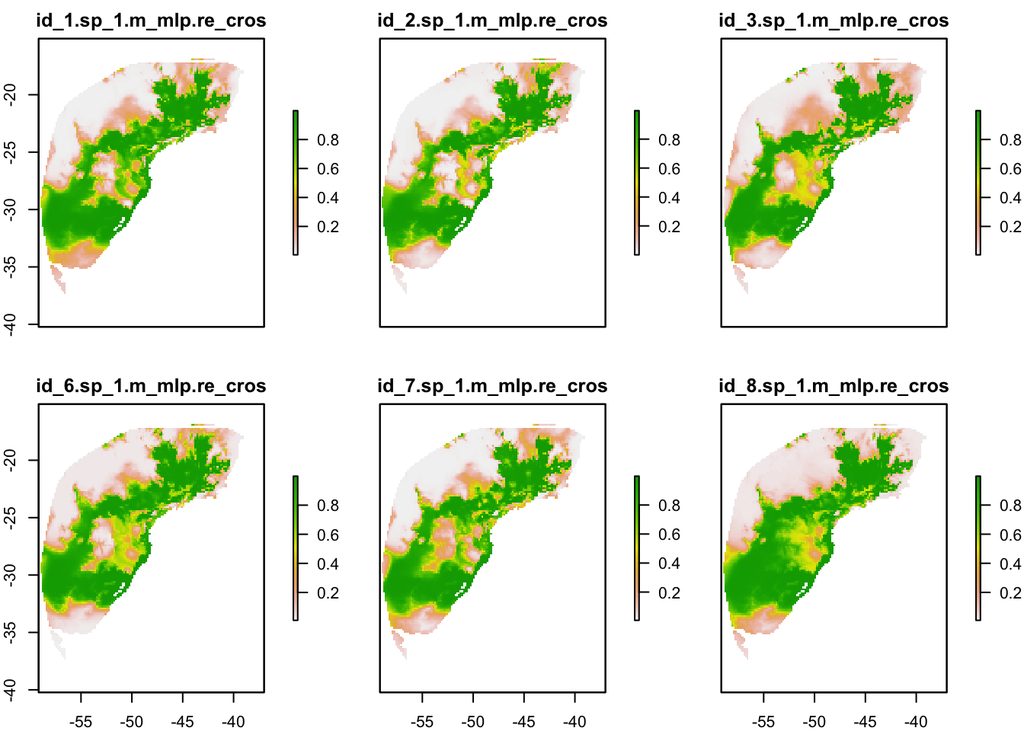

```r
plot(p)
```

Para projetar o modelo no futuro, seguimos a mesma ideia, mas alterando os preditores no argumento `newdata`:

```r
p_fut <- predict(m,
                 newdata=s_fut,
                 w=ids_mean)
p_fut
```

```
## class      : RasterBrick
## dimensions : 130, 133, 17290, 6  (nrow, ncol, ncell, nlayers)
## resolution : 0.1666667, 0.1666667  (x, y)
## extent     : -59.16667, -37, -38.5, -16.83333  (xmin, xmax, ymin, ymax)
## crs        : +proj=longlat +datum=WGS84 +no_defs
## source     : sdm_prediction_tfvkwx.grd
## names      : id_1.sp_1.m_mlp.re_cros, id_2.sp_1.m_mlp.re_cros, id_3.sp_1.m_mlp.re_cros, id_6.sp_1.m_mlp.re_cros, id_7.sp_1.m_mlp.re_cros, id_8.sp_1.m_mlp.re_cros
## min values :            0.0037771231,            0.0001027099,            0.0047818394,            0.0086453380,            0.0050018122,            0.0090655899
## max values :               0.9992166,               0.9966624,               0.9987082,               0.9992117,               0.9987488,               0.9985825
## fullname   : id_1-species_Ficus.cestrifolia-method_mlp-replication_cross_validation, id_2-species_Ficus.cestrifolia-method_mlp-replication_cross_validation, id_3-species_Ficus.cestrifolia-method_mlp-replication_cross_validation, id_6-species_Ficus.cestrifolia-method_mlp-replication_cross_validati…
```

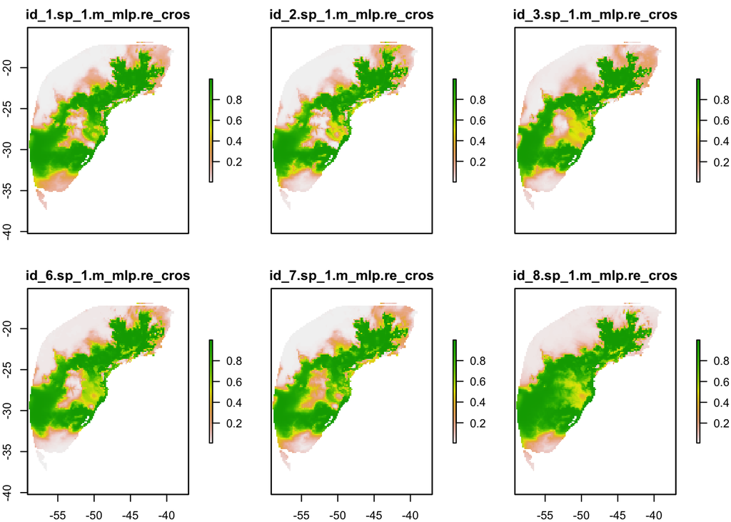

```r
plot(p_fut)
```

Assim é um tanto difícil entender os resultados. Vamos tentar uní-los para obter um panorama melhor.

## Montando um ensemble

Para unir os rasters que montamos anteriormente, podemos somar manualmente um a um, ou fazer uma média entre eles, ou tantas outras opções que possam ser imaginadas. No entanto, existe uma função no pacote sdm que otimiza esse passo. A função `ensemble` junta a função `predict` com os processos de ensemble. Dessa forma, ao invés de gerar os mapas que geramos com a função `predict`, podemos pular direto para a função `ensemble`. Essa função possui o mesmo formato da anterior, mas ainda aceita o argumento `setting` para que possamos determinar como será feito o ensemble. As opções aqui são inúmeras e podem ser conferidas na página de ajuda da função. O único argumento que muda aqui é o argumento `w` que agora passa a se chamar `id`.

```r
e <- ensemble(m,
              newdata=s,
              id=ids_mean,
              setting = list(method = "unweighted"))
e
```

```
## class      : RasterLayer
## dimensions : 130, 133, 17290  (nrow, ncol, ncell)
## resolution : 0.1666667, 0.1666667  (x, y)
## extent     : -59.16667, -37, -38.5, -16.83333  (xmin, xmax, ymin, ymax)
## crs        : +proj=longlat +datum=WGS84 +no_defs
## source     : sdm_ensemble_8xy2m3.grd
## names      : layer
## values     : 0.008141697, 0.995181  (min, max)
```

Perceba que, agora, apenas um raster foi criado: a média dos modelos.

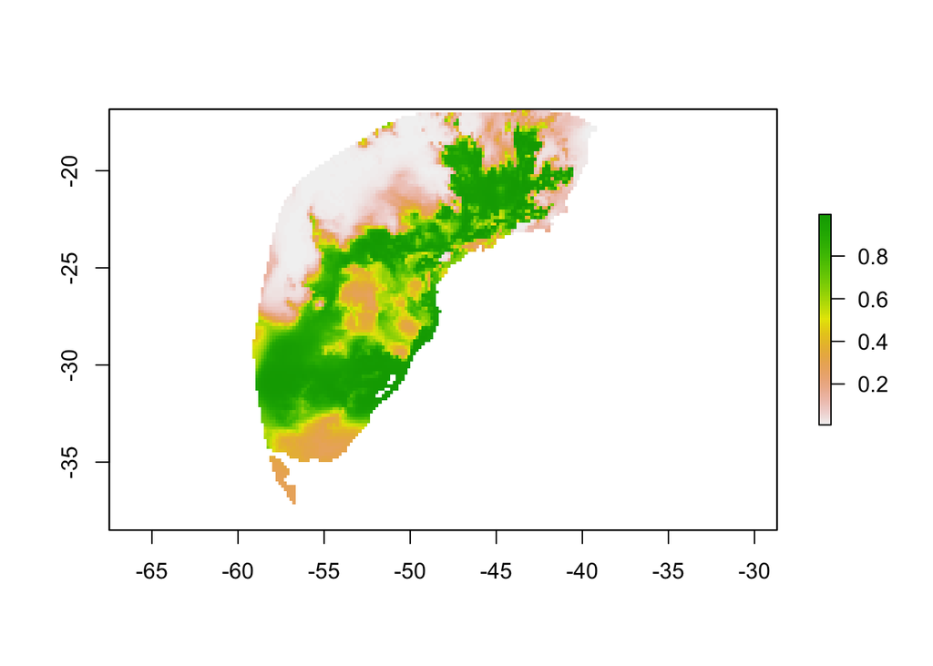

```r
plot(e)
```

Vamos repetir para o futuro:

```r
e_fut <- ensemble(m,
                  newdata=s_fut,
                  id=ids_mean,
                  setting = list(method = "unweighted"))
e_fut
```

```
## class      : RasterLayer
## dimensions : 130, 133, 17290  (nrow, ncol, ncell)
## resolution : 0.1666667, 0.1666667  (x, y)
## extent     : -59.16667, -37, -38.5, -16.83333  (xmin, xmax, ymin, ymax)
## crs        : +proj=longlat +datum=WGS84 +no_defs
## source     : sdm_ensemble_u7gvox.grd
## names      : layer
## values     : 0.008148703, 0.9951505  (min, max)
```

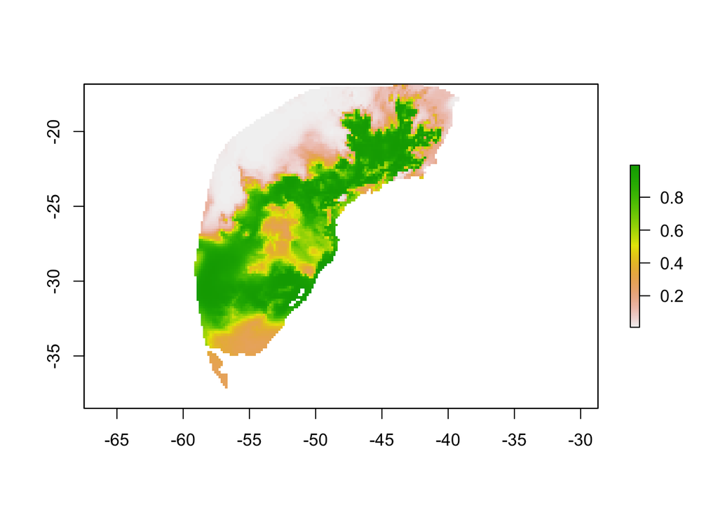

```r
plot(e_fut)
```

É possível também gerar dados de incerteza usando os métodos `'uncertainty'` e `'pa'`.

## Conclusão

Projetar os modelos que geramos é o principal objetivo das modelagens de distribuição de espécies. Modelos que não são projetados são apenas modelos de nicho. Da mesma forma, usar um ensemble para sumarizar os resultados é importante para termos ideia da variacão entre eles. Rgiões com maior consistência (menor variação), podem ser consideradas como regiões aonde o resultado é “mais correto”.

## Exercício

Agora é a sua vez de por a mão na massa. Tendo em mente o último bloco de código deste roteiro, alterne os tipos de métodos que existem para gerar um ensemble. Você percebe alguma mudança nos resultados? Quais deles é mais apropriado? Existe algum mais apropriado?

## Bônus: Como projetar em diversos cenários:

Nesses caso, para otimizar, podemos usar um loop que passará entre os cenários. Para os dados que temos aqui neste roteiro, teríamos:

```r
scenarios <- c("s","s_fut")
for (j in scenarios) {
       print(paste0("Ensemble: ", j))
       assign(paste0("e_",j]), ensemble(m,
                                        newdata=get(j),
                                        id=ids_mean,
                                        setting=list(method='unweighted'))
}
```